# Classification_Titanic_ProjectA

Project A : Titanic - Likely Survival

Owner: Reema Lad

IMS ID No. : IMSPRO143500

Tuesday, August 25, 2020

# Problem Statement

The sinking of the RMS Titanic is one of the most infamous shipwrecks in history. On April 15, 1912, during her maiden voyage, the Titanic sank after colliding with an iceberg, killing numerous passengers and crew. This sensational tragedy shocked the international community and led to better safety regulations for ships.  
One of the reasons that the shipwreck led to such loss of life was that there were not enough lifeboats for the passengers and crew. Although there was some element of luck involved in surviving the sinking, some groups of people were more likely to survive than others, such as women, children, and the upper-class.  
In this, we ask you to complete the analysis of what sorts of people were likely to survive. In particular, we ask you to apply the tools of machine learning to predict which passengers survived the tragedy.

# **Data Description**

> **survived** == Survival == 0 : No, 1 : Yes  
> **Pclass** == Ticket class == 1 : 1st, 2 : 2nd, 3 : 3rd  
> **Sex** == Sex  
> **Age** == Age in years  
> **Sibsp** == # of siblings / spouses aboard the Titanic  
> **Parch** == # of parents / children aboard the Titanic  
> **Ticket** == Ticket number  
> **Fare** == Passenger fare  
> **Cabin** == Cabin number  
> **embarked** == Port of Embarkation == C : Cherbourg, Q : Queenstown, S : Southampton

# **Process**

1. Import Libraries
2. Load Data
3. Reading Raw Data
4. Missing Values Computation
5. Visualization
6. Missing Value Imputation
7. Feature Engineering & UniVariate - BiVariate Analysis
8. Model Building
9. Predictions
10. Presentation

# Importing Libraries

```python
# Basic Packages
import pandas as pd
import os as os
import numpy as np
import warnings
warnings.filterwarnings("ignore")

#Data Spliting
from sklearn.model_selection import train_test_split

#Feature Refinment
from sklearn.preprocessing import LabelEncoder,OneHotEncoder #Encoder

#Data Analysis & Model Building
import scipy.stats as stats #Anova
from scipy.stats import chi2_contingency #ChiSquare
from sklearn.ensemble import RandomForestClassifier
from sklearn.linear_model import LogisticRegression
from sklearn.naive_bayes import GaussianNB
from sklearn.metrics import accuracy_score
from sklearn.svm import SVC
from sklearn.svm import LinearSVC
from sklearn.tree import DecisionTreeClassifier
from sklearn.neighbors import KNeighborsClassifier
from sklearn.ensemble import GradientBoostingClassifier
from sklearn.ensemble import AdaBoostClassifier
from sklearn.metrics import confusion_matrix
from sklearn.metrics import accuracy_score

#Visuals
%matplotlib inline
import matplotlib.pyplot as plt
import seaborn as sns

# For Error Evaluation
```

# Loading Data

```python
filepath = r"D:\IMS\DataBase"
filename = "Classification_Titanic_ProjectA_train.csv"
original_data = pd.read_csv(os.path.join(filepath, filename))
```

# Reading Raw Data

```python
original_data.head(8)
```

|  | PassengerId | Survived | Pclass | Name | Sex | Age | SibSp | Parch | Ticket | Fare | Cabin | Embarked |
| --- | --- | --- | --- | --- | --- | --- | --- | --- | --- | --- | --- | --- |
| 0 | 1 | 0 | 3 | Braund, Mr. Owen Harris | male | 22.0 | 1 | 0 | A/5 21171 | 7.2500 | NaN | S |
| 1 | 2 | 1 | 1 | Cumings, Mrs. John Bradley (Florence Briggs Th... | female | 38.0 | 1 | 0 | PC 17599 | 71.2833 | C85 | C |
| 2 | 3 | 1 | 3 | Heikkinen, Miss. Laina | female | 26.0 | 0 | 0 | STON/O2. 3101282 | 7.9250 | NaN | S |
| 3 | 4 | 1 | 1 | Futrelle, Mrs. Jacques Heath (Lily May Peel) | female | 35.0 | 1 | 0 | 113803 | 53.1000 | C123 | S |
| 4 | 5 | 0 | 3 | Allen, Mr. William Henry | male | 35.0 | 0 | 0 | 373450 | 8.0500 | NaN | S |
| 5 | 6 | 0 | 3 | Moran, Mr. James | male | NaN | 0 | 0 | 330877 | 8.4583 | NaN | Q |
| 6 | 7 | 0 | 1 | McCarthy, Mr. Timothy J | male | 54.0 | 0 | 0 | 17463 | 51.8625 | E46 | S |
| 7 | 8 | 0 | 3 | Palsson, Master. Gosta Leonard | male | 2.0 | 3 | 1 | 349909 | 21.0750 | NaN | S |

```python
print("Number of Rows:",original_data.shape[0])
print("Number of Columns:",original_data.shape[1])
```

```
Number of Rows: 891
Number of Columns: 12
```

```python
print("Data Column Names:\n", original_data.columns)
```

```
Data Column Names:
 Index(['PassengerId', 'Survived', 'Pclass', 'Name', 'Sex', 'Age', 'SibSp',
       'Parch', 'Ticket', 'Fare', 'Cabin', 'Embarked'],
      dtype='object')
```

```python
original_data.info()
```

```
<class 'pandas.core.frame.DataFrame'>
RangeIndex: 891 entries, 0 to 890
Data columns (total 12 columns):
 #   Column       Non-Null Count  Dtype
---  ------       --------------  -----
 0   PassengerId  891 non-null    int64
 1   Survived     891 non-null    int64
 2   Pclass       891 non-null    int64
 3   Name         891 non-null    object
 4   Sex          891 non-null    object
 5   Age          714 non-null    float64
 6   SibSp        891 non-null    int64
 7   Parch        891 non-null    int64
 8   Ticket       891 non-null    object
 9   Fare         891 non-null    float64
 10  Cabin        204 non-null    object
 11  Embarked     889 non-null    object
dtypes: float64(2), int64(5), object(5)
memory usage: 83.7+ KB
```

```python
print("Expected Non-Null Values In Dataframe : ",891*12)
print("Actual Non-Null Values In Dataframe : ", original_data.count().sum())
```

```
Expected Non-Null Values In Dataframe :  10692
Actual Non-Null Values In Dataframe :  9826
```

```python
original_data.describe()
```

|  | PassengerId | Survived | Pclass | Age | SibSp | Parch | Fare |
| --- | --- | --- | --- | --- | --- | --- | --- |
| count | 891.000000 | 891.000000 | 891.000000 | 714.000000 | 891.000000 | 891.000000 | 891.000000 |
| mean | 446.000000 | 0.383838 | 2.308642 | 29.699118 | 0.523008 | 0.381594 | 32.204208 |
| std | 257.353842 | 0.486592 | 0.836071 | 14.526497 | 1.102743 | 0.806057 | 49.693429 |
| min | 1.000000 | 0.000000 | 1.000000 | 0.420000 | 0.000000 | 0.000000 | 0.000000 |
| 25% | 223.500000 | 0.000000 | 2.000000 | 20.125000 | 0.000000 | 0.000000 | 7.910400 |
| 50% | 446.000000 | 0.000000 | 3.000000 | 28.000000 | 0.000000 | 0.000000 | 14.454200 |
| 75% | 668.500000 | 1.000000 | 3.000000 | 38.000000 | 1.000000 | 0.000000 | 31.000000 |
| max | 891.000000 | 1.000000 | 3.000000 | 80.000000 | 8.000000 | 6.000000 | 512.329200 |

```python
original_data.describe(include='all')
```

|  | PassengerId | Survived | Pclass | Name | Sex | Age | SibSp | Parch | Ticket | Fare | Cabin | Embarked |
| --- | --- | --- | --- | --- | --- | --- | --- | --- | --- | --- | --- | --- |
| count | 891.000000 | 891.000000 | 891.000000 | 891 | 891 | 714.000000 | 891.000000 | 891.000000 | 891 | 891.000000 | 204 | 889 |
| unique | NaN | NaN | NaN | 891 | 2 | NaN | NaN | NaN | 681 | NaN | 147 | 3 |
| top | NaN | NaN | NaN | Rouse, Mr. Richard Henry | male | NaN | NaN | NaN | 1601 | NaN | B96 B98 | S |
| freq | NaN | NaN | NaN | 1 | 577 | NaN | NaN | NaN | 7 | NaN | 4 | 644 |
| mean | 446.000000 | 0.383838 | 2.308642 | NaN | NaN | 29.699118 | 0.523008 | 0.381594 | NaN | 32.204208 | NaN | NaN |
| std | 257.353842 | 0.486592 | 0.836071 | NaN | NaN | 14.526497 | 1.102743 | 0.806057 | NaN | 49.693429 | NaN | NaN |
| min | 1.000000 | 0.000000 | 1.000000 | NaN | NaN | 0.420000 | 0.000000 | 0.000000 | NaN | 0.000000 | NaN | NaN |
| 25% | 223.500000 | 0.000000 | 2.000000 | NaN | NaN | 20.125000 | 0.000000 | 0.000000 | NaN | 7.910400 | NaN | NaN |
| 50% | 446.000000 | 0.000000 | 3.000000 | NaN | NaN | 28.000000 | 0.000000 | 0.000000 | NaN | 14.454200 | NaN | NaN |
| 75% | 668.500000 | 1.000000 | 3.000000 | NaN | NaN | 38.000000 | 1.000000 | 0.000000 | NaN | 31.000000 | NaN | NaN |
| max | 891.000000 | 1.000000 | 3.000000 | NaN | NaN | 80.000000 | 8.000000 | 6.000000 | NaN | 512.329200 | NaN | NaN |

# *Insights*

Total 891 rows and 12 columns in data  
There are missing values (null) in dataframe as against expected 10,692 values available are only 9,826  
Values of "Survived", "Pclass", "Embarked" need to be treated for appropriate data type  
**As we are to predict "likelihood of survival", "Survived" is the Dependent/Output Variable.**

# Missing Values Computation

```python
missing_df = pd.DataFrame(original_data.isnull().sum(), columns = ["No. of Missing Rows"])
missing_df["Missing %"] = missing_df["No. of Missing Rows"]*100/original_data.shape[0]
missing_df["Missing %"] = missing_df["Missing %"].round(2)
missing_df.sort_values(by='Missing %',ascending=False)
```

|  | No. of Missing Rows | Missing % |
| --- | --- | --- |
| Cabin | 687 | 77.10 |
| Age | 177 | 19.87 |
| Embarked | 2 | 0.22 |
| PassengerId | 0 | 0.00 |
| Survived | 0 | 0.00 |
| Pclass | 0 | 0.00 |
| Name | 0 | 0.00 |
| Sex | 0 | 0.00 |
| SibSp | 0 | 0.00 |
| Parch | 0 | 0.00 |
| Ticket | 0 | 0.00 |
| Fare | 0 | 0.00 |

```python
original_data.loc[original_data.Embarked.isnull()]
```

|  | PassengerId | Survived | Pclass | Name | Sex | Age | SibSp | Parch | Ticket | Fare | Cabin | Embarked |
| --- | --- | --- | --- | --- | --- | --- | --- | --- | --- | --- | --- | --- |
| 61 | 62 | 1 | 1 | Icard, Miss. Amelie | female | 38.0 | 0 | 0 | 113572 | 80.0 | B28 | NaN |
| 829 | 830 | 1 | 1 | Stone, Mrs. George Nelson (Martha Evelyn) | female | 62.0 | 0 | 0 | 113572 | 80.0 | B28 | NaN |

```python
original_data.loc[original_data.Age.isnull()]
```

|  | PassengerId | Survived | Pclass | Name | Sex | Age | SibSp | Parch | Ticket | Fare | Cabin | Embarked |
| --- | --- | --- | --- | --- | --- | --- | --- | --- | --- | --- | --- | --- |
| 5 | 6 | 0 | 3 | Moran, Mr. James | male | NaN | 0 | 0 | 330877 | 8.4583 | NaN | Q |
| 17 | 18 | 1 | 2 | Williams, Mr. Charles Eugene | male | NaN | 0 | 0 | 244373 | 13.0000 | NaN | S |
| 19 | 20 | 1 | 3 | Masselmani, Mrs. Fatima | female | NaN | 0 | 0 | 2649 | 7.2250 | NaN | C |
| 26 | 27 | 0 | 3 | Emir, Mr. Farred Chehab | male | NaN | 0 | 0 | 2631 | 7.2250 | NaN | C |
| 28 | 29 | 1 | 3 | O'Dwyer, Miss. Ellen "Nellie" | female | NaN | 0 | 0 | 330959 | 7.8792 | NaN | Q |
| ... | ... | ... | ... | ... | ... | ... | ... | ... | ... | ... | ... | ... |
| 859 | 860 | 0 | 3 | Razi, Mr. Raihed | male | NaN | 0 | 0 | 2629 | 7.2292 | NaN | C |
| 863 | 864 | 0 | 3 | Sage, Miss. Dorothy Edith "Dolly" | female | NaN | 8 | 2 | CA. 2343 | 69.5500 | NaN | S |
| 868 | 869 | 0 | 3 | van Melkebeke, Mr. Philemon | male | NaN | 0 | 0 | 345777 | 9.5000 | NaN | S |
| 878 | 879 | 0 | 3 | Laleff, Mr. Kristo | male | NaN | 0 | 0 | 349217 | 7.8958 | NaN | S |
| 888 | 889 | 0 | 3 | Johnston, Miss. Catherine Helen "Carrie" | female | NaN | 1 | 2 | W./C. 6607 | 23.4500 | NaN | S |

177 rows × 12 columns

```python
original_data.loc[original_data.Cabin.isnull()]
```

|  | PassengerId | Survived | Pclass | Name | Sex | Age | SibSp | Parch | Ticket | Fare | Cabin | Embarked |
| --- | --- | --- | --- | --- | --- | --- | --- | --- | --- | --- | --- | --- |
| 0 | 1 | 0 | 3 | Braund, Mr. Owen Harris | male | 22.0 | 1 | 0 | A/5 21171 | 7.2500 | NaN | S |
| 2 | 3 | 1 | 3 | Heikkinen, Miss. Laina | female | 26.0 | 0 | 0 | STON/O2. 3101282 | 7.9250 | NaN | S |
| 4 | 5 | 0 | 3 | Allen, Mr. William Henry | male | 35.0 | 0 | 0 | 373450 | 8.0500 | NaN | S |
| 5 | 6 | 0 | 3 | Moran, Mr. James | male | NaN | 0 | 0 | 330877 | 8.4583 | NaN | Q |
| 7 | 8 | 0 | 3 | Palsson, Master. Gosta Leonard | male | 2.0 | 3 | 1 | 349909 | 21.0750 | NaN | S |
| ... | ... | ... | ... | ... | ... | ... | ... | ... | ... | ... | ... | ... |
| 884 | 885 | 0 | 3 | Sutehall, Mr. Henry Jr | male | 25.0 | 0 | 0 | SOTON/OQ 392076 | 7.0500 | NaN | S |
| 885 | 886 | 0 | 3 | Rice, Mrs. William (Margaret Norton) | female | 39.0 | 0 | 5 | 382652 | 29.1250 | NaN | Q |
| 886 | 887 | 0 | 2 | Montvila, Rev. Juozas | male | 27.0 | 0 | 0 | 211536 | 13.0000 | NaN | S |
| 888 | 889 | 0 | 3 | Johnston, Miss. Catherine Helen "Carrie" | female | NaN | 1 | 2 | W./C. 6607 | 23.4500 | NaN | S |
| 890 | 891 | 0 | 3 | Dooley, Mr. Patrick | male | 32.0 | 0 | 0 | 370376 | 7.7500 | NaN | Q |

687 rows × 12 columns

# *Insights*

Highest missing values are in *Cabin*, 77%. Ideally in this senario we need to drop the field, however will have some more insights, correlation and interpretations before doing so.  
*Age* has almost 20% missing values, will categorize and impute the same.  
Lastly *Embarked* has only two values missing, will replace the same with Mode post checking corelated parameters.  
**Also as our output variable is categorical and we will be dealing with Classification problem here, will try to convert as many data values to categorical type for better computation**

# Data Visualization

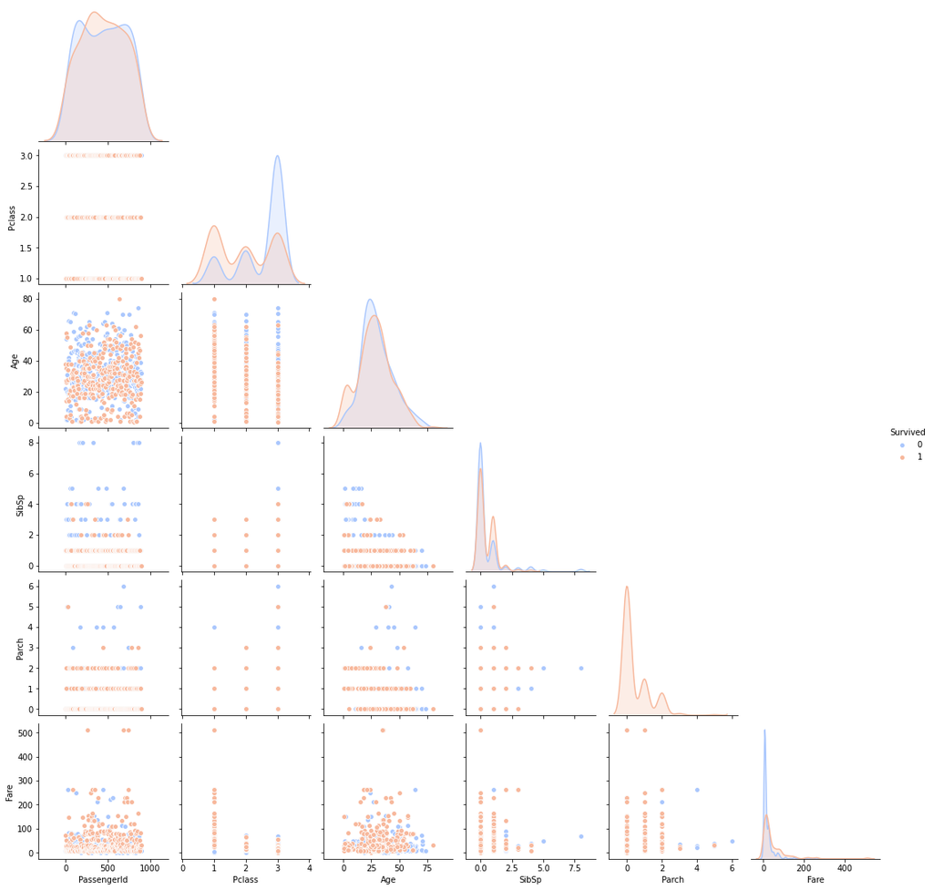

```python
sns.pairplot(original_data,hue='Survived', palette="coolwarm", corner=True) #kind="reg"
```

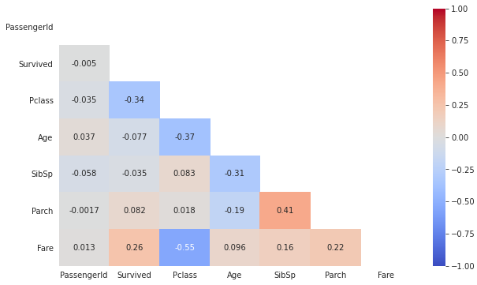

```python
num_corr = original_data.corr()
mask = np.zeros_like(num_corr)
mask[np.triu_indices_from(mask)] = True
with sns.axes_style("white"):
    f, ax = plt.subplots(figsize=(10, 6))
    ax = sns.heatmap(num_corr , mask=mask, vmin = -1,vmax=1, annot = True, cmap="coolwarm")
```

# *Insights*

At the face of it, Pclass and Age looks influencing the Survival possibilities. Also the Fare has a noticeable distribution however, at this point I assume the Fare will be directly dependent on Pclass.  
Also other categorical variables needs to be looked still checked like sex.  
Lastly will have a look on the input variable dependencies as well as their interpretation post transforming to categorical  
**Will complete missing value imputation at this stage for better data visualization as factors like age are playing noticeable role and has about 20% missing values**

# Missing Value Imputation

```python
# Copy of original dataframe for missing value imputation and datatype change
data_1 = original_data.copy()
data_1.head(2)
```

|  | PassengerId | Survived | Pclass | Name | Sex | Age | SibSp | Parch | Ticket | Fare | Cabin | Embarked |
| --- | --- | --- | --- | --- | --- | --- | --- | --- | --- | --- | --- | --- |
| 0 | 1 | 0 | 3 | Braund, Mr. Owen Harris | male | 22.0 | 1 | 0 | A/5 21171 | 7.2500 | NaN | S |
| 1 | 2 | 1 | 1 | Cumings, Mrs. John Bradley (Florence Briggs Th... | female | 38.0 | 1 | 0 | PC 17599 | 71.2833 | C85 | C |

## Embarked

```python
print("\n",data_1['Survived'].groupby(data_1['Embarked']).count())
print("\n Total Missing Values in 'Embarked' ",original_data['Embarked'].isna().sum())
```

```
 Embarked
C    168
Q     77
S    644
Name: Survived, dtype: int64

 Total Missing Values in 'Embarked'  2
```

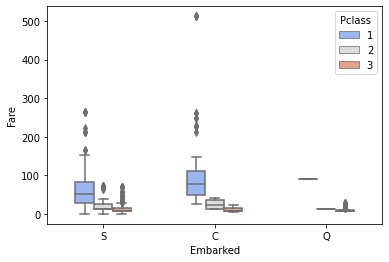

```python
sns.boxplot(x="Embarked", y="Fare", hue="Pclass", data=data_1, width = 0.5, palette="coolwarm")
```

```python
print("\n Maximum passangers embarked in Southampton (S) - could replace missing values with mode i.e. S, however \n the missing values pertain to passangers who travelled in 1st Pclass with 80$ Fare. \n As 1st Pclass median is around 80$ Fare for Embarked in Cherbourg, hence replacing missing value with C : Cherbourg")
data_1["Embarked"] = data_1["Embarked"].fillna('C')
# data_1['Embarked'][data_1['Embarked'].isna()==True]=data_1['Embarked'].mode()[0]
print("\n NaN values of 'Embarked' in new DataSet : ", data_1['Embarked'].isna().sum())
print("\n", data_1['Survived'].groupby(data_1['Embarked']).count())
print("\n Embarked in Cherbourg changed from",(original_data[original_data["Embarked"] == "C"].shape[0]),
      "numbers to",(data_1[data_1["Embarked"] == "C"].shape[0]))
```

```
 Maximum passangers embarked in Southampton (S) - could replace missing values with mode i.e. S, however
 the missing values pertain to passangers who travelled in 1st Pclass with 80$ Fare.
 As 1st Pclass median is around 80$ Fare for Embarked in Cherbourg, hence replacing missing value with C : Cherbourg

 NaN values of 'Embarked' in new DataSet :  0

 Embarked
C    170
Q     77
S    644
Name: Survived, dtype: int64

 Embarked in Cherbourg changed from 168 numbers to 170
```

## Age

```python
data_1['Age'].isna().sum()
```

```
177
```

```python
# Checking Corelation with other variables
data_1.corr()
```

|  | PassengerId | Survived | Pclass | Age | SibSp | Parch | Fare |
| --- | --- | --- | --- | --- | --- | --- | --- |
| PassengerId | 1.000000 | -0.005007 | -0.035144 | 0.036847 | -0.057527 | -0.001652 | 0.012658 |
| Survived | -0.005007 | 1.000000 | -0.338481 | -0.077221 | -0.035322 | 0.081629 | 0.257307 |
| Pclass | -0.035144 | -0.338481 | 1.000000 | -0.369226 | 0.083081 | 0.018443 | -0.549500 |
| Age | 0.036847 | -0.077221 | -0.369226 | 1.000000 | -0.308247 | -0.189119 | 0.096067 |
| SibSp | -0.057527 | -0.035322 | 0.083081 | -0.308247 | 1.000000 | 0.414838 | 0.159651 |
| Parch | -0.001652 | 0.081629 | 0.018443 | -0.189119 | 0.414838 | 1.000000 | 0.216225 |
| Fare | 0.012658 | 0.257307 | -0.549500 | 0.096067 | 0.159651 | 0.216225 | 1.000000 |

```python
# Creating database with Non Null Age to better map and visualization corelation
data_age = data_1[data_1.Age.isna()==False]
data_age.info()
```

```
<class 'pandas.core.frame.DataFrame'>
Int64Index: 714 entries, 0 to 890
Data columns (total 12 columns):
 #   Column       Non-Null Count  Dtype
---  ------       --------------  -----
 0   PassengerId  714 non-null    int64
 1   Survived     714 non-null    int64
 2   Pclass       714 non-null    int64
 3   Name         714 non-null    object
 4   Sex          714 non-null    object
 5   Age          714 non-null    float64
 6   SibSp        714 non-null    int64
 7   Parch        714 non-null    int64
 8   Ticket       714 non-null    object
 9   Fare         714 non-null    float64
 10  Cabin        185 non-null    object
 11  Embarked     714 non-null    object
dtypes: float64(2), int64(5), object(5)
memory usage: 72.5+ KB
```

```python
# Checking Corelation with other variables
print("Corelation With Respect to Survived: \n",data_age.corr()["Survived"])
print("\n Corelation With Respect to Age : \n", data_age.corr()["Age"])
```

```
Corelation With Respect to Survived:
 PassengerId    0.029340
Survived       1.000000
Pclass        -0.359653
Age           -0.077221
SibSp         -0.017358
Parch          0.093317
Fare           0.268189
Name: Survived, dtype: float64

 Corelation With Respect to Age :
 PassengerId    0.036847
Survived      -0.077221
Pclass        -0.369226
Age            1.000000
SibSp         -0.308247
Parch         -0.189119
Fare           0.096067
Name: Age, dtype: float64
```

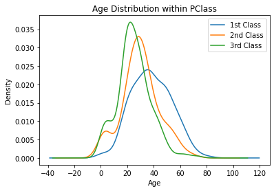

```python
data_age.Age[data_age.Pclass == 1].plot(kind='kde')
data_age.Age[data_age.Pclass == 2].plot(kind='kde')
data_age.Age[data_age.Pclass == 3].plot(kind='kde')
plt.xlabel("Age")
plt.title("Age Distribution within PClass")
plt.legend(('1st Class', '2nd Class','3rd Class'),loc='best') ;
```

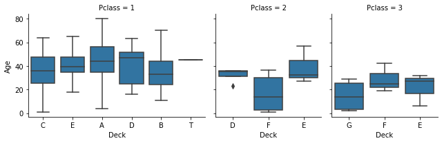

```python
#Assuming Cabin initial letter is nomenclature for the Deck on the Ship we separate the same for visualization
data_age["Deck"]=data_1.Cabin.str[0]
data_age.assign(Deck=data_age.Deck.astype(object)).sort_values(by='Deck')
g = sns.FacetGrid(data_age, col="Pclass", palette="coolwarm", sharex=False,
                  gridspec_kws={"width_ratios": [5, 3, 3]})
g.map(sns.boxplot, "Deck", "Age")
```

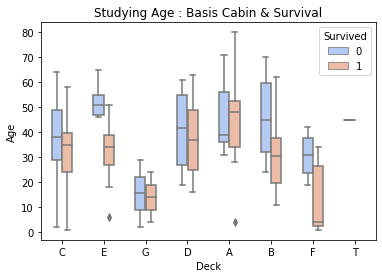

```python
sns.boxplot(x="Deck", y="Age", hue="Survived", data=data_age, width = 0.5, palette="coolwarm")
plt.title("Studying Age : Basis Cabin & Survival")
```

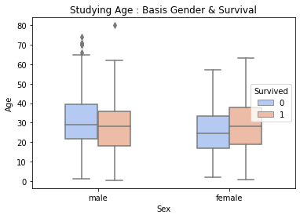

```python
sns.boxplot(x="Sex", y="Age", hue="Survived", data=data_age, width = 0.5, palette="coolwarm")
plt.title("Studying Age : Basis Gender & Survival")
```

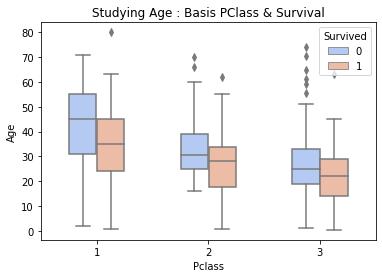

```python
sns.boxplot(x="Pclass", y="Age", hue="Survived", data=data_age, width = 0.5, palette="coolwarm")
plt.title("Studying Age : Basis PClass & Survival")
```

*Not much of insights so far, except for Pclass in which 1st Class has higher age scale compared to 2nd and 3rd Class. Hence trying to have some insigts by grouping the age basis the Name Title with Pclass and Survived*

```python
title = data_1['Name'].str.extract('([A-Za-z]+)\.', expand=False)
data_1['Title'] = title

pd.crosstab(data_1['Title'],data_1['Sex'])
```

| Sex Title | female | male |
| --- | --- | --- |
| Capt | 0 | 1 |
| Col | 0 | 2 |
| Countess | 1 | 0 |
| Don | 0 | 1 |
| Dr | 1 | 6 |
| Jonkheer | 0 | 1 |
| Lady | 1 | 0 |
| Major | 0 | 2 |
| Master | 0 | 40 |
| Miss | 182 | 0 |
| Mlle | 2 | 0 |
| Mme | 1 | 0 |
| Mr | 0 | 517 |
| Mrs | 125 | 0 |
| Ms | 1 | 0 |
| Rev | 0 | 6 |
| Sir | 0 | 1 |

```python
#replace various titles with more common ones, Rare ones with 'Ot' i.e. Others, Royals to 'Ryl' & Master to 'Mst'
data_1['Title'] = data_1['Title'].replace(['Lady', 'Capt', 'Col', 'Don', 'Dr', 'Major', 'Rev', 'Jonkheer', 'Dona'], 'Ot')
data_1['Title'] = data_1['Title'].replace(['Countess', 'Lady', 'Sir'], 'Ryl')
data_1['Title'] = data_1['Title'].replace('Mlle', 'Ms')
data_1['Title'] = data_1['Title'].replace('Ms', 'Ms')
data_1['Title'] = data_1['Title'].replace('Mme', 'Mrs')
data_1['Title'] = data_1['Title'].replace('Master', 'Mst')
data_1['Title'] = data_1['Title'].replace('Miss', 'Ms')

data_1[['Title', 'Survived']].groupby(['Title'], as_index=False).count()
```

|  | Title | Survived |
| --- | --- | --- |
| 0 | Mr | 517 |
| 1 | Mrs | 126 |
| 2 | Ms | 185 |
| 3 | Mst | 40 |
| 4 | Ot | 21 |
| 5 | Ryl | 2 |

```python
#Changing Title's from 'Object' to Category for better usability
title_categories = {"Mr": 1, "Ms": 2, "Mrs": 3, "Mst": 4, "Ryl": 5, "Ot": 6}
data_1['Cat_Title'] = data_1['Title'].map(title_categories)
```

```python
data_1[['Cat_Title', 'Survived']].groupby(['Cat_Title'], as_index=False).count()
```

|  | Cat_Title | Survived |
| --- | --- | --- |
| 0 | 1 | 517 |
| 1 | 2 | 185 |
| 2 | 3 | 126 |
| 3 | 4 | 40 |
| 4 | 5 | 2 |
| 5 | 6 | 21 |

```python
#Changing Title's from 'Int' to Category for better usability
data_1["Age_Mod"] = data_1["Age"].fillna(-0.5) # Missing value populated
age_bins = [-1, 0, 5, 12, 18, 24, 35, 60, 100, np.inf] # -1 are the missing value
age_labels = ['Unknown', 'Infant', 'Child', 'Teenager', 'Young Adult', 'Adult', 'Senior Adult', 'Old', 'Others']
# labels as per general demography split
data_1['Age_Group'] = pd.cut(data_1["Age_Mod"], age_bins, labels = age_labels)
data_1[['Age_Group', 'Survived']].groupby(['Age_Group'], as_index=False).count()
```

|  | Age_Group | Survived |
| --- | --- | --- |
| 0 | Unknown | 177 |
| 1 | Infant | 44 |
| 2 | Child | 25 |
| 3 | Teenager | 70 |
| 4 | Young Adult | 138 |
| 5 | Adult | 220 |
| 6 | Senior Adult | 195 |
| 7 | Old | 22 |
| 8 | Others | 0 |

*Filling missing Age values from mode of age's in categorized age group pertaining to the same title.*

```python
data_age_fill = data_1[data_1.Age.isna()==False]
Mr_Age = data_age_fill[data_age_fill["Cat_Title"] == 1]["Age_Group"].mode() # Output : Adult
Ms_Age = data_age_fill[data_age_fill["Cat_Title"] == 2]["Age_Group"].mode() # Output : Young Adult
Mrs_Age = data_age_fill[data_age_fill["Cat_Title"] == 3]["Age_Group"].mode() # Output : Senior Adult
Mst_Age = data_age_fill[data_age_fill["Cat_Title"] == 4]["Age_Group"].mode() # Output : Infant
Ryl_Age = data_age_fill[data_age_fill["Cat_Title"] == 5]["Age_Group"].mode() # Output : Adult
Ot_Age = data_age_fill[data_age_fill["Cat_Title"] == 6]["Age_Group"].mode() # Output : Senior Adult
Age_Title_Mapping = {1: "Adult", 2: "Young Adult", 3: "Senior Adult", 4: "Infant", 5: "Adult", 6: "Senior Adult"}

for x in range(len(data_1["Age_Group"])):
    if data_1["Age_Group"][x] == "Unknown":
        data_1["Age_Group"][x] = Age_Title_Mapping[data_1["Cat_Title"][x]]
```

```python
# Deleting Age related Dataframes as would not require beyond this point
del data_age
del data_age_fill
```

```python
#map Cat_Age value to numerical value
Age_Mapping = {'Infant': 1, 'Child': 2, 'Teenager': 3, 'Young Adult': 4, 'Adult': 5, 'Senior Adult': 6, 'Old': 7, 'Others' : 8}
data_1['Cat_Age'] = data_1['Age_Group'].map(Age_Mapping)
```